# Continuous WFO equity and performance

S&P 500 · frozen annual WFO · 2019–2025 · conservative contingent-right scenario

**1,760 / 1,760 sessions · 84 / 84 months · one continuous equity path.**  
1,758 days use observed/recovered returns; two use explicit conservative rights marks. Long rights = $0; short rights = full payout cap. Later claim P&L is excluded. This is an accounting scenario, not newly recovered market data.

## Full-period performance under the policy

| strategy | Total return* | CAGR* | Max drawdown* | Sharpe* | Ann. volatility* | Sortino* | Calmar* |
| --- | --- | --- | --- | --- | --- | --- | --- |
| LongOnly | 54.52% | 6.43% | -16.40% | 0.766 | 8.62% | 1.062 | 0.392 |
| MACD | -3.66% | -0.53% | -8.52% | -0.157 | 3.10% | -0.207 | -0.063 |
| LinReg | 48.91% | 5.87% | -16.18% | 0.746 | 8.08% | 1.035 | 0.363 |
| GMOM | 46.82% | 5.65% | -16.05% | 0.733 | 7.94% | 1.015 | 0.352 |
| RegCombo | 45.46% | 5.51% | -15.93% | 0.728 | 7.79% | 1.010 | 0.346 |
| SignCombo | 47.87% | 5.76% | -16.12% | 0.740 | 8.00% | 1.026 | 0.357 |

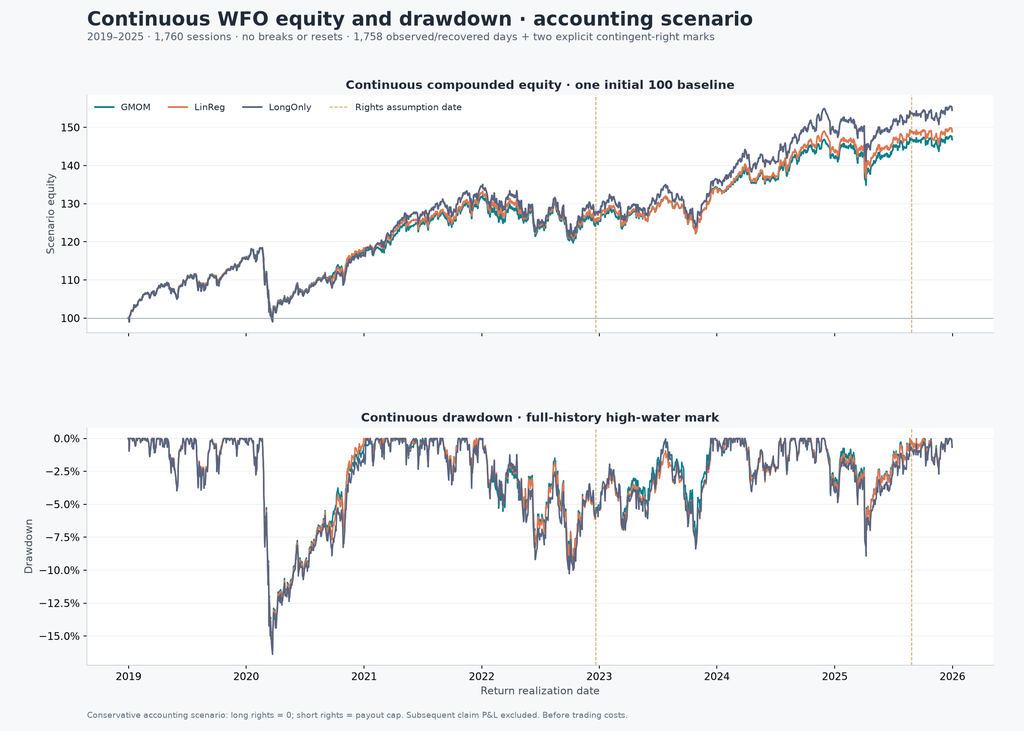

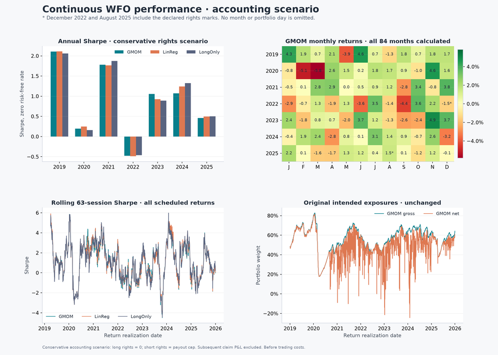

## The two assumed GMOM days

| Stock | Date | GMOM entry weight | Assumed right mark | GMOM portfolio-day return |
| --- | --- | --- | --- | --- |
| ABMD | 2022-12-22 | -0.04134% | $35.00 | -0.03224% |
| WBA | 2025-08-28 | 0.23533% | $0.00 | -0.12456% |

The cash/right terms come from [the Abiomed completion announcement](https://www.sec.gov/Archives/edgar/data/200406/000119312522311072/d428734dex991.htm) and [Nasdaq’s Walgreens notice](https://classic.nasdaqtrader.com/TraderNews.aspx?id=ECA2025-463).

## Event-mark sensitivity

| strategy | CAGR range* | Total-return range* |
| --- | --- | --- |
| GMOM | 5.6523% – 5.6618% | 46.8163% – 46.9085% |
| LinReg | 5.8668% – 5.8763% | 48.9104% – 49.0039% |
| LongOnly | 6.4284% – 6.4380% | 54.5164% – 54.6135% |
| MACD | -0.5331% – -0.5264% | -3.6642% – -3.6190% |
| RegCombo | 5.5115% – 5.5210% | 45.4550% – 45.5464% |
| SignCombo | 5.7607% – 5.7696% | 47.8709% – 47.9582% |

## Definitions, verification and limits

- *All path metrics are conditional on the declared contingent-right accounting scenario, including subsequent claim P&L being zero. Two source valuations are still unobserved; those dates are visibly flagged as assumptions.
- Cash consideration is recognized at face value. Long non-traded rights are marked zero; short obligations are reserved at their full contractual payout cap. The rule follows position sign, never whichever mark improves test performance.
- The claim register retains the rights/obligations. No right is assumed sold. Later payouts, fair-value changes, reserve releases and financing are excluded; this is not a fully reconciled realized cash-flow ledger.
- The four alternative zero/face event-mark combinations use the same exclusion of subsequent claim P&L. Their envelope measures only the two initial-mark assumptions and is not a bound on actual strategy wealth with later cash flows.
- All 1,758 observed or previously recovered portfolio days, every forecast, position, cohort and original model are unchanged. No stock label is invented and no whole portfolio return is replaced by zero, dropped or reweighted.
- Equity starts at 100 once and compounds all 1,760 scheduled daily returns. Drawdown uses the running high-water mark including initial capital. All 84 monthly returns compound every scheduled session.
- CAGR annualizes with 252 trading sessions. Sharpe uses sample daily volatility and zero risk-free rate. Sortino uses a zero return threshold. LongOnly is the inverse-volatility-sized cohort, not a capitalization-weighted index.
- The existing research-proxy limits remain: executable fills, trading costs, borrow/financing, source identity certification and complete training-feature repairs are not supplied by this report.

Independent verification replayed 12 assumed strategy/event returns from the original holdings, checked every monthly return, and confirmed a single uninterrupted path for each strategy. Maximum event-return error: 9.97e-17.